# Helstejenester og helseforsikring (kap. 4 og kap. 9)

# Helse og helsetjenester

## 9.1 Introduksjon

- Synspunktet om at «helsetjenester er en grunnleggende rettighet og bør derfor tilbys av staten» er ulogisk fordi ordene ‘og derfor’ ikke følger av det opprinnelige premisset
  - mat er også en grunnleggende rettighet, og den leveres godt nok av privat sektor!
- I hele OECD regulerer og finansierer myndighetene helsetjenester, og ofte også leverer helsetjenester

**Hvorfor?**

## 9.2 Hva er målene med helsetjenester?

- Målet: Bedre helse
- Kilder til god helse:
  - levestandard (inntekt/formue osv.)
  - individuelle valg
  - generell miljø
  - en persons miljø
  - kvalitet av og tilgang til helsetjenester
  - arv, f.eks. fysisk eller emosjonell styrke
- helsepolitikken bør inkludere alle de fem første punktene

## 9.2.2 Effektivitet: Hvordan måle nytte og kostnader av bedre helse?

- Måling av kostnader
  - gjennomførbart
- Nytte vanskelig å kvantifisere
  - helse er vanskelig å måle
  - kausalitet er kompleks
  - vanskelig å finne verdien av forbedret helse
- https://ourworldindata.org/grapher/life-expectancy-vs-health-expenditure

## 9.2.3 Måling av fordelingen av helse og helsetjenester

- Fordelingen av helse:
  - Forventet levealder (én mulig proxy for helse)øker i mange land
    - Men forventet levealder varierer betydelig, både mellom land og innad i et land

[figure not shown]

- Fordelingen av helsetjenester: - hvis et rikt individ betaler i gjennomsnitt mer enn et fattig individ i hvilken som helst skatt som brukes til å betale for helsetjenester, men mottar samme mengde helsetjenester, omfordeler systemet fra rik til fattig (dvs. er progressiv)

## 9.3.1 Teoretiske argumenter for offentlige inngrep: markedssvikt: effektivitet

- **ufullkommen konkurranse**:
  - et begrenset antall sykehus i markedet
  - i små lokalsamfunn vil det dessuten ikke være praktisk mulig å skape konkurranse ved å ha mange små sykehus side om side
    - sykehusene har derfor sterk “markedsmakt” i sitt geografiske område
- **stordriftsfordeler**
  - sykehusdrift innebærer store faste kostnader i form av bygninger, maskiner og medisinsk utstyr
    - betyr falllende gjenomsnittskostnader ==> naturlig monopol
- **(positive) eksternaliteter**:
  - når en person er frisk, gir dette ikke bare nytte for vedkommende selv, men også for familien og arbeidsplassen
    - dersom han selv skal vurdere hva han er villig til å betale for en behandling som gjør han frisk, vil han ikke nødvendigvis ta hensyn til familiens og arbeidsplassens nytte (positiv eksternalitet) ==> for lavt konsum av helsetjenester
    - vaksinering mot koronavirus gjør at jeg ikke blir smittet (privat nytte)
      - om jeg ikke tar hensyn til at min vaksine reduserer smittefaren for andre (positiv eksternalitet) ==> for lavt konsum av vaksine
    - **offentlig inngrep**: positive eksternaliteter gjør at et rent privat markedssystem gir for lavt konsum av helsetjenester offentlig subsidiering kan derfor være ønskelig for å gi et samfunnsøkonomisk optimalt kvantum

## Positive eksternaliteter i helse

```
# A tibble: 2 × 2
      x     y
  <dbl> <dbl>
1  4.65  3.40
2  6.28  4.79
```

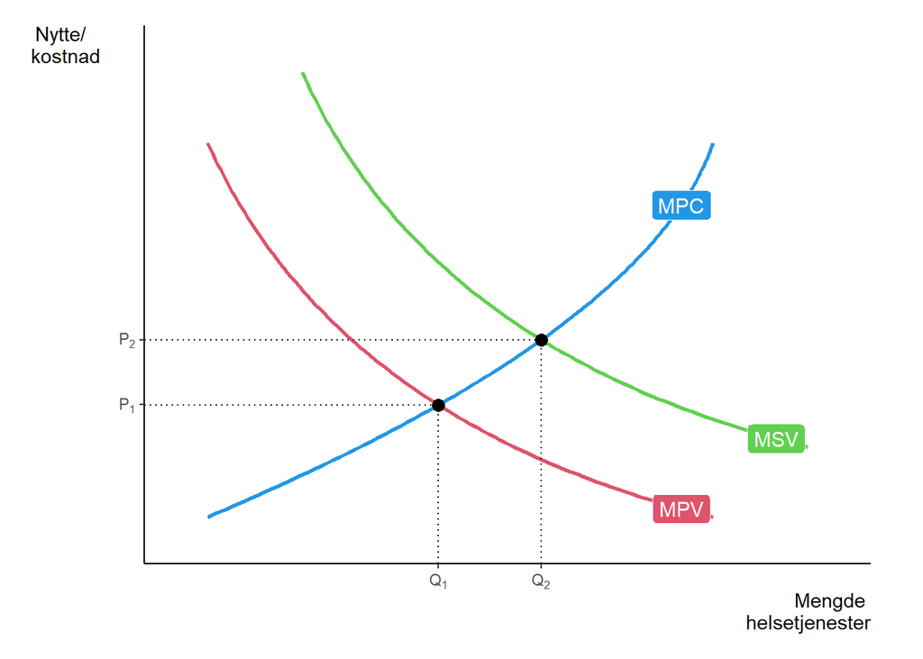

```r
library(econocharts)
library(ggplot2)


# Add custom curves
demand1 <- data.frame(Hmisc::bezier(c(1, 3, 9),
                                    c(9, 3, 1)))

demand2 <- data.frame(Hmisc::bezier(c(2.5, 4.5, 10.5),
                                    c(10.5, 4.5, 2.5)))

supply1 <- data.frame(Hmisc::bezier(c(1, 8, 9),
                                    c(1, 5, 9)))
#with bezier
supply2 <- data.frame(Hmisc::bezier(c(1, 8, 9),
                                    c(1, 5, 9) -2.55))
#without bezier, the same answer
supply2 <- data.frame(x = supply1$x, y = supply1$y - 2.55)

# Supply and demand curves - externalities
sdcurve(supply1, demand1, demand2,supply1,
        names = c("MPC", "MPV","MSV", "MPC"),
        xlab = "Mengde \n helsetjenester", ylab = "Nytte/ \n kostnad")
```

## Positive eksternaliteter i helse og subsidiering

```
# A tibble: 3 × 2
      x     y
  <dbl> <dbl>
1  4.65  3.40
2  6.28  4.79
3  6.28  2.23
```

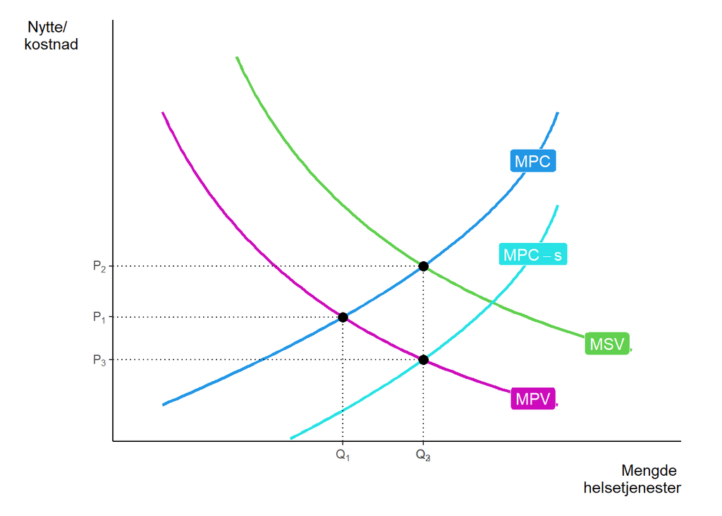

```r
# Last inn nødvendige pakker
library(econocharts)
library(ggplot2)


# Add custom curves
demand1 <- data.frame(Hmisc::bezier(c(1, 3, 9),
                                    c(9, 3, 1)))

demand2 <- data.frame(Hmisc::bezier(c(2.5, 4.5, 10.5),
                                    c(10.5, 4.5, 2.5)))

supply1 <- data.frame(Hmisc::bezier(c(1, 8, 9),
                                    c(1, 5, 9)))
#with bezier
supply2 <- data.frame(Hmisc::bezier(c(1, 8, 9),
                                    c(1, 5, 9) -2.55))
#without bezier, the same answer
supply2 <- data.frame(x = supply1$x, y = supply1$y - 2.55)

# Supply and demand curves -exteranlities and subsidies
sdcurve(supply1, demand1, demand2,supply1,supply2,demand1,
        names = c("MPC", "MPV","MSV", "MPC","MPC-s","MPV"),
        xlab = "Mengde \n helsetjenester", ylab = "Nytte/ \n kostnad")
```

## **Usikkerhet og ufullkommen informasjon**

- **betydelig** usikkerhet knyttet til om, når og i hvilket omfang vi får behov for helsetjenester
  - usikkerheten reiser et behov for helseforsikring for å gi oss økonomisk trygghet
- når vi først har blitt syke, er det vanskelig å vite hvilken effekt ulike behandlinger og helsetjenester har
  - ikke gjentatte transaksjoner av helsetjenester –> kan ikke basere sine beslutninger på erfaring med produktet eller tjenesteyteren
- ufullkommen informasjon om kvaliteten
- vanskelig å vite hva noe er verdt

## **Rasjonell adferd**?

- begrenset rasjonalitet
  - selv om informasjon er tilgjengelig, er helsetjenester komplekse, slik at det er en grense for hva forbrukerne kan forstå uten selv å være helsepersonell
  - prokrastrinering
  - problemer med å prosessere informasjon
  - desperate pasienter er ikke rasjonelle prisbevisste aktører som gjør optimale nyttekostnadsavveininger

## Implikasjoner av begrenset rasjonalitet og informasjonsproblemer

```
# A tibble: 3 × 2
      x     y
  <dbl> <dbl>
1  4.65  3.40
2  6.28  4.79
3  7.69  6.36
```

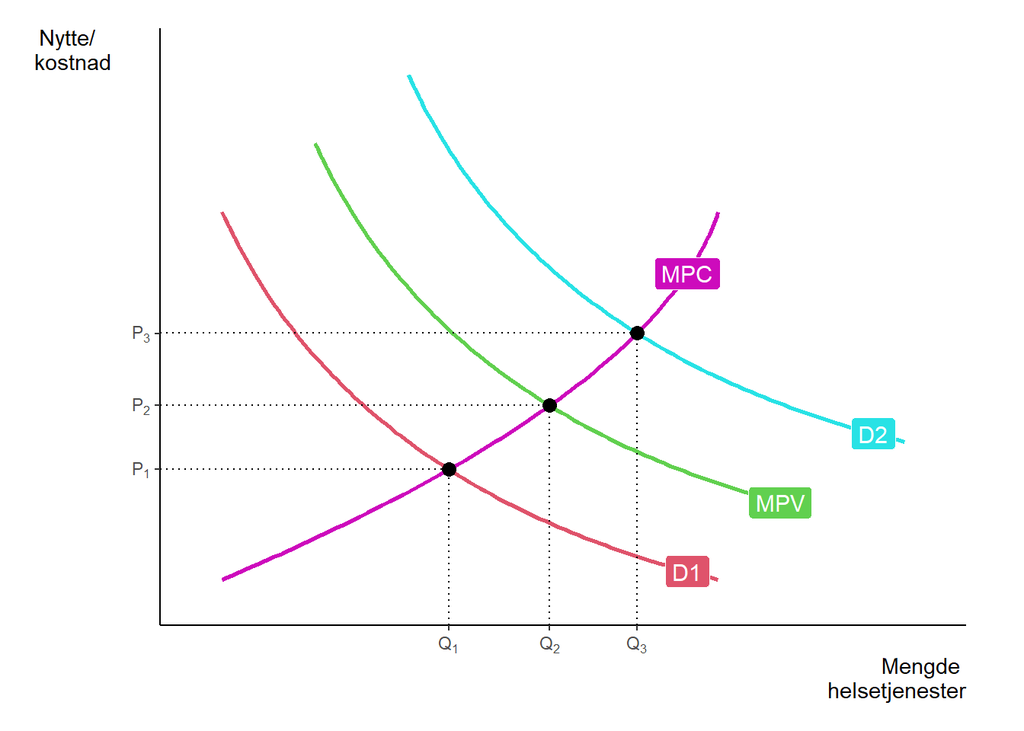

```r
library(econocharts)
library(ggplot2)

demand1 <- data.frame(Hmisc::bezier(c(1, 3, 9),
                                    c(9, 3, 1)))

demand2 <- data.frame(Hmisc::bezier(c(2.5, 4.5, 10.5),
                                    c(10.5, 4.5, 2.5)))

demand3 <- data.frame(Hmisc::bezier(c(4, 6, 12),
                                  c(12, 6, 4)))

supply1 <- data.frame(Hmisc::bezier(c(1, 8, 9),
                                    c(1, 5, 9)))

# Supply and demand curves
sdcurve(supply1, demand1, demand2 , supply1, demand3,supply1,
        names = c("MPC", "D1","MPV","MPC","D2","MPC"),
        xlab = "Mengde \n helsetjenester", ylab = "Nytte/ \n kostnad")
```

## Offentlige inngrep pga. informasjonsproblemer

- mange behandlingsvalg delegeres til legen, som fungerer som en agent for pasienten
- reguleringer, slik som at kun individer med godkjente kvalifikasjoner kan praktisere medisin
- ved alvorlige informasjons- og atferdsproblemer kan markeder bli ineffektive
  - betydelige reguleringer av privat produksjon eller offentlig produksjon
- **Ufullstendige kontrakter**:
  - et betydelig problem, gitt kompleksiteten i mye av medisinsk behandling
- **Asymmetrisk informasjon**
  - en av de viktigste formene av markedssvikt på helsesektoren
  - i **markedet for helsetjenester** er det leger og sykehus som er bedre informert enn pasientene
  - i **helseforsikringsmarkedet** er det konsumenter som ønsker å kjøpe forsikring som vet mer
    - vet mer om egen helsetilstand og tilbøyeligheten til å bruke helsetjenester enn det forsikringsselskapet gjør

## Helseforsikring

- to typer usikkerhet gir opphav til etterspørselen etter økonomisk trygghet:
  - folk vet ikke om de noen gang vil få behov for helsetjenester
  - de kjenner ikke til de fulle økonomiske implikasjonene av sykdom
  - helseforsikring vil fjerne - eller i det minste redusere - slike økonomiske usikkerheter forbundet med fremtidige sykdommer
  - risikopreferanser varierer, men de fleste mennesker er **risikoaverse** når det gjelder de økonomiske tapene forbundet med dårlig helse, og etterspør helseforsikring
- anta at individene er risikoaverse
  - de foretrekker et sikkert beløp fremfor et usikkert lotteri med samme forventningsverdi
  - forventet nytteteori: teorien for valg under usikkerhet, basert på Von Neumann-Morgenstern forventet nytteteori (se bl.a. McGuire et al., 1988)
  - antar at individene står overfor usikre beslutningsalternativer
    - individene kjenner sannsynlighetene for de ulike utfallene
  - en aktør som er risikoavers vil ha en strengt konkav nyttefunksjon, som tilsier at marginalnytten av inntekt er avtakende: $U’(Y)>0$, $U’’(Y)<0$
  - regnet i penger, tjener individet ingenting på å ha forsikring
  - menden uforsikrede situasjonen gir et lavere nivå av nytte
    - det som refereres til som velferdsgevinsten fra forsikring, illustreres ved den vertikale avstanden fra A til B

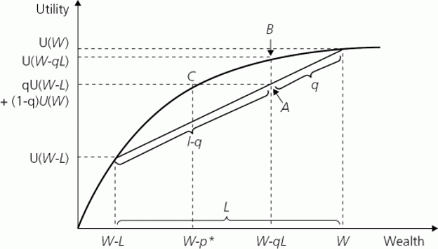

- støttevideo finner du [her](https://uit.cloud.panopto.eu/Panopto/Pages/Viewer.aspx?id=c06b2713-ad3e-4e86-8d9f-b07700b670b3)
- Idéen bak helseforsikring:
  - det finnes et stort antall individer med uavhengig risiko for å bli rammet (av sykdom), og alle betaler inn et beløp tilsvarende de forventede (helse-)utgiftene til et fond, så vil fondet få inn et tilstrekkelig beløp til å kunne dekke opp for de personene som får behov for behandling
- Aktuarisk nøytral forsikringspremie (aktuariell premie)
- Innbetalingen er lik forventet utbetaling for forsikringsselskapet (for enhver risikogruppe)
- Forsikringspremien er lik forventet tap ved skade for forsikringstaker

der

$p_i$ = sannsynligheten for at begivenheten vil inntreffe

$L$ = størrelsen på tapet

$α$ = transaksjonskostnader o.l.

## Hva hvis helseforsikringen var tibudt privat?

- forsikring (definisjon):
  - et redskap for å beskytte enkeltpersoner mot risiko
  - en aktuarisk mekanisme
    - et forsikringsselskap må regne ut hvor mye en kunde skal betale for en forsikring på forhånd
    - aktuarisk nøytral forsikringspremie (aktuariell premie)
      - innbetalingen er lik forventet utbetaling for forsikringsselskapet (for enhver risikogruppe)
      - forsikringspremien er lik forventet tap ved skade for forsikringstaker

$$\pi_i = (1+α) q_iL,$$

der

$q_i$ = sannsynligheten for at begivenheten vil inntreffe

$L$ = størrelsen på tapet

$α$ = transaksjonskostnader o.l.

## Privat tilbud av helseforsikring er ineffektivt

$$\pi_i = (1+α) q_iL$$

- for at privat tilbudte forsikringer vil være effektive:
  - de individuelle sannsynlighetene for sykdom ($q_i$) er uavhengig av hverandre (ingen systematisk risiko)
    - markedssvikt: felles sjokk i stedet for individuell risiko
      - gjensidig avhengige sannsynligheter
    - må ha usikkerhet, dvs. manglende kunnskap om framtidig utfall $q_i \le 1$ - om $q_i = 1$, da blir $qi = (1+α)L > L$
      - markedsvikt: sikkerhet i stedet for risiko, det vil si sannsynlighet for sykdom nærmer seg en
    - må kjenne risiko (sannsynlighet må være kjent eller mulig å estimere (forsikringsselskapet må vite gjennomsnittlig $q_i$)
      - markedssvikt: usikkerhet, det vil si at risikoen ikke er kjent eller mulig å estimere
    - ingen asymmetrisk informasjon
      - ingen **uheldig utvalg**
        - forsikringsselskapet kjenner ikke individuelle $q_i$ og forsikring er frivillig
          - Økende andel dårlig risiko
      - ingen **atferdsrisiko** (moralsk hasard)
        - Individene kan påvirke $q_i$ (eller $L$)
          - Påvirke $q_i$ (ex ante moralsk hasard)
            - forsikringstakeren kan påvirke sannsynlighet for tap eller størrelse på potensielt tap, gjennom strategisk adferdsendring
              - for eksempel ingen forebygging
          - Påvirke $L$ (ex post moralsk hasard)
            - knyttes til endret adferd fra forsikringstakeren etter at risikoen er inntruffet, men før kompensasjonskravet sendes til selskapet
            - forsikringstakeren har derfor mulighet til å påvirke skadebeløpet, og derfor kompensasjonsbeløpet

## Uheldig utvalg

- når de med lavest risiko velger å stå utenfor forsikringsordningen, mens kun de med høy risiko velger å benytte seg av den
- oppstår som følge av skjevfordelt informasjon mellom forsikringstaker og forsikringstilbyder, og fører til økonomiske tap for sistnevnte dersom de ikke finner måter å avsløre de ulike risikogruppene
- folk har ulik sykdomsrisiko som skyldes genetiske og arvelige forhold: de er utenfor individets kontroll (eksogene)
- forsikringsselskapet har ikke kjennskap til hvilke kunder som tilhører hvilken risikogruppe
- anta at vi har to befolkningsgrupper: en lavrisikogruppe ($L$) og en høyrisikogruppe ($H$)
  - $H$ har høyere sykdomsrisiko enn $L$: $p_H > p_L$
- **dersom forsikringsselskapene har full informasjon**
  - kan risikojustere premiene slik at hver av de to gruppene oppnår ulike kontrakter
    - $L$ tilbys kontrakten $C_L$
    - $H$ tilbys $C_H$
      - betaler en høyere premie
  - selskapet kan tilby full og aktuarisk rettferdig (kompensasjonen er lik det økonomiske tapet) forsikring til alle
    - **dette er ikke er mulig, da sykdomsrisiko er privat informasjon for hvert individ**
      - kan ikke identifisere hvem som er $H$ og hvem som er $L$
      - $H$-gruppen vil da kunne kjøpe $L$-gruppens kontrakter –> forsikringsselskapet vil gå i minus
  - Løsning #1: tilby samme kontrakt til alle, basert på den gjennomsnittlige risikoen
    - $H$ vil synes dette er et godt tilbud
      - premien er lavere enn forventede tap
    - $L$ vil oppleve avtalen som lite attraktiv – > kan trekke seg ut av markedet –> forsikringsselskapet blir kun sittende igjen med de med høy risiko –> **ugunstig utvalg**
    - For å unngå underskudd, vil selskapet øke premiene –> de beste blant de dårlige forsvinner fra markedet –> kan hende at premien må settes så høyt at alle trekker seg ut –> **markedet bryter sammen**
  - Løsning #2: tilby $L$ mindre enn full forsikringsdekning
    - lite attraktiv for $H$-gruppen –> vil heller velge å kjøpe den forsikringen som er ment for deres type
  - Resultatet av både løsninger er at $L$-gruppen må bære kostnadene ved informasjonsasymmetri
- I praksis løser forsikringsselskapene dette ved å innhente så mye informasjon som mulig om individenes sykdomsrisiko

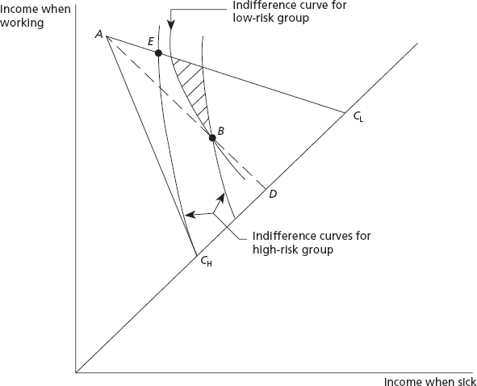

Uheldig utvalg

- støttevideoer finner du på Tema 2s videoforelesningsbank

## Atferdsrisiko ex ante

- helseatferden kan endres som følge av at man er forsikret
  - forsikringstakeren kan ved sin egen atferd påvirke størrelsen på selskapets forventede tap på måter som ikke kan observeres av selskapet
    - forsikring kan redusere insentivene f.eks. til forebygging
      - forebygging reduserer sannsynligheten, $q$, for at skaden skal inntreffe
    - forsikringstakeren kan hevde at han driver med forebyggende aktivitet uten at han i realiteten gjør det
      - selskapet kan ikke verifisere dette

## Atferdsrisiko ex post

- helseforsikring kan påvirke aktørenes atferd etter at sykdom har oppstått
  - full forsikring innebærer at pasientene ikke stilles overfor den sanne prisen ved forbruk av helsetjenester
    - egenbetalingen er lik null –> konsumentene blir oppmuntret til å etterspørre flere helsetjenester enn det de ellers ville gjort –> nytten av forbruket er mindre enn marginalkostnadene
    - **fører til at utgiftene til helsetjenester blir større enn det som er optimalt sett fra samfunnets side**
- To sentrale problemstillinger:
  - hvorvidt er det optimalt eller ønskelig å ha full forsikringsdekning?
  - hvor høye bør egenandelene være?

## Egenandel

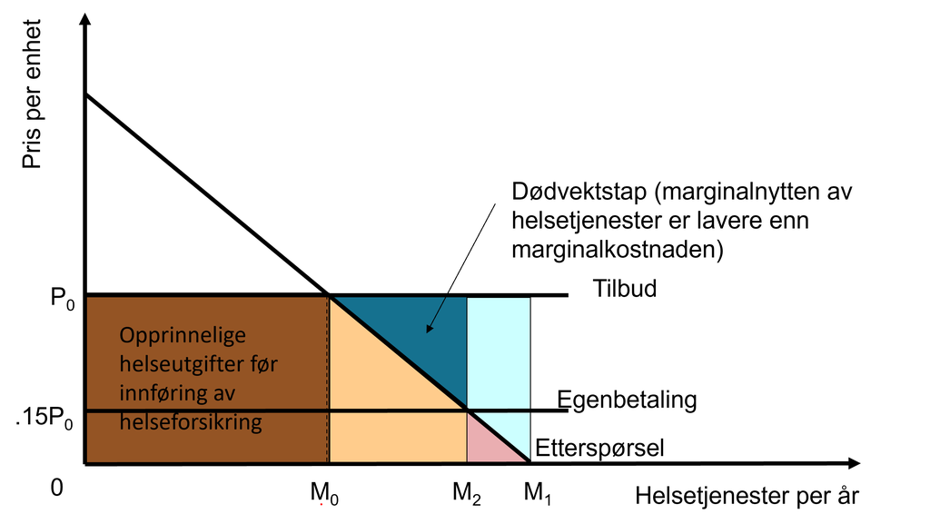

Effekten av egenandeler

- gratis forbruk kan føre til overforbruk –> en samfunnsøkonomisk ineffektiv ressursbruk
  - størrelsen vil avhenge av hvor elastisk etterspørselen er
    - elastisk etterspørsel
      - velferdstapet ved overforbruk betydelig
    - uelastisk etterspørsel
      - effektivitetstapet blir mindre dersom elastisiteten går mot null

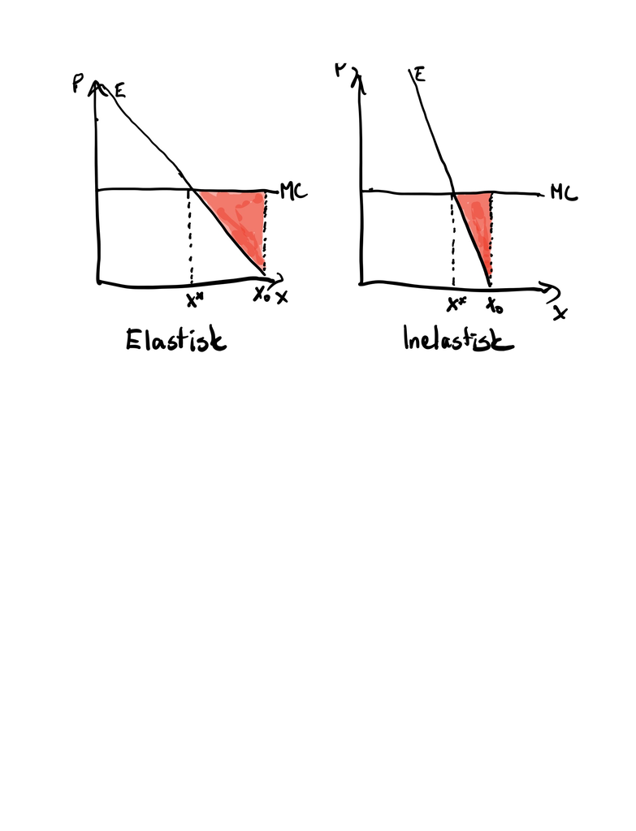

Priselastisitet og effektivitetstap

## Fører helseforsikring til overforbruk?

- avhenger av hvor prisfølsom etterspørselen etter helsetjenester er
  - vertikal etterspørselskurve: optimalt med full forsikringsdekning
    - pasient etterspør den samme mengden uavhengig av om han er forsikret eller ikke
      - behandlingbeslutningene påvirkes i liten grad av prisen
        - optimalt med lave egenandeler og høy forsikringsdekning
    - gratis forbruk (100 % helseforsikring) –> ingen effektivitetskostnader.
  - meget elastisk etterspørsel: optimalt med egenandeler
    - full forsikringsdekning medfører større etterspørsel
    - optimalt med høye egenandeler og lav forsikringsdekning
- egenandelene bør være høyere desto sterkere konsumentene responderer på prisendringer
- egenbetaling har gunstige insentiveffekter, men det eliminerer samtidig gevinstene ved forsikring, og kan også ha uheldige fordelingsmessige konsekvenser
  - de som har størst behov, er ofte de som har lavest betalingsvillighet til å bære egenandelene
  - påvirker ikke forbruket like mye for dem med høy betalingsvillighet
  - en avveining mellom bruken av egenandeler, et effektiv nivå på forbruket av helsetjenester og fordelings- og velferdseffekter ved full forsikringsdekning

## Aktuariell privat helseforsikring: Hva predikerer økonomisk teori?

- Hull i dekning vil oppstå
  - for kroniske eksisterende medisinske problemer og for eldres medisinske behov, hvor sannsynligheten for å trenge behandling er høy
  - for medisinsk behandling knyttet til individuelle valg slik som graviditet og fødsel
  - fødsel
- uforsikrede risikoaverse individer, som står overfor uforholdsmessig høye premier på grunn av uheldig utvalg
- ukontrollerte økninger i medisinske utgifter på grunn av insitamenter ved tredjeparts betalinger, noe som ville fører til økende press på forsikringspremier

## 9.3.2 Teoretiske argumenter for offentlige inngrep: rettferdighet

- Horisontal likhet
  - ufullkommen informasjon kan være knyttet til sosioøkonomisk klasse
    - inngrep: regulering knyttet til helsepersonells kvalifikasjoner, medisiner, og medisinske fasiliteter.
  - subsidier kan adressere underforbruk grunnet mangelfull informasjon
- Vertikal likhet
  - handler om omfordeling fra rike til fattige
  - offentlig leverte helsetjenester kan være omfordelende
    - om rike betaler mer skatt, men bruker tjenester mindre